# Appendix 1 - King County house price prediction

## Part 1 - Multi-Linear Regression Model

### Step 1 : Collecting Data

The data set is collected in CSV format from kaggele and below is the reference for the same.

Harlfoxem. (2016) House sales in king county, usa. [Online]. Available:https://www.kaggle.com/harlfoxem/housesalesprediction

### Step 2 : Exploring, preprocessing and cleaning the data

Primary setup

```r
knitr::opts_knit$set(root.dir = '/Users/sobil/Documents/MSC/Sem 1/Data Mining & Machine Learning/Project/Kc_house/')
remove(list = ls())
```

#### 1) reading the raw csv file

```r
kc_house <- read.csv("kc_house_data.csv", stringsAsFactors = FALSE)
```

#### 2) exploratory analysis

Structure of the kc_house data frame

```r
str(kc_house)
```

```
'data.frame':   21613 obs. of  21 variables:
 $ id           : num  7.13e+09 6.41e+09 5.63e+09 2.49e+09 1.95e+09 ...
 $ date         : chr  "20141013T000000" "20141209T000000" "20150225T000000" "20141209T000000" ...
 $ price        : num  221900 538000 180000 604000 510000 ...
 $ bedrooms     : int  3 3 2 4 3 4 3 3 3 3 ...
 $ bathrooms    : num  1 2.25 1 3 2 4.5 2.25 1.5 1 2.5 ...
 $ sqft_living  : int  1180 2570 770 1960 1680 5420 1715 1060 1780 1890 ...
 $ sqft_lot     : int  5650 7242 10000 5000 8080 101930 6819 9711 7470 6560 ...
 $ floors       : num  1 2 1 1 1 1 2 1 1 2 ...
 $ waterfront   : int  0 0 0 0 0 0 0 0 0 0 ...
 $ view         : int  0 0 0 0 0 0 0 0 0 0 ...
 $ condition    : int  3 3 3 5 3 3 3 3 3 3 ...
 $ grade        : int  7 7 6 7 8 11 7 7 7 7 ...
 $ sqft_above   : int  1180 2170 770 1050 1680 3890 1715 1060 1050 1890 ...
 $ sqft_basement: int  0 400 0 910 0 1530 0 0 730 0 ...
 $ yr_built     : int  1955 1951 1933 1965 1987 2001 1995 1963 1960 2003 ...
 $ yr_renovated : int  0 1991 0 0 0 0 0 0 0 0 ...
 $ zipcode      : int  98178 98125 98028 98136 98074 98053 98003 98198 98146 98038 ...
 $ lat          : num  47.5 47.7 47.7 47.5 47.6 ...
 $ long         : num  -122 -122 -122 -122 -122 ...
 $ sqft_living15: int  1340 1690 2720 1360 1800 4760 2238 1650 1780 2390 ...
 $ sqft_lot15   : int  5650 7639 8062 5000 7503 101930 6819 9711 8113 7570 ...
```

Summary of the kc_house data frame

```r
summary(kc_house)
```

```
       id                date               price            bedrooms
 Min.   :1.000e+06   Length:21613       Min.   :  75000   Min.   : 0.000
 1st Qu.:2.123e+09   Class :character   1st Qu.: 321950   1st Qu.: 3.000
 Median :3.905e+09   Mode  :character   Median : 450000   Median : 3.000
 Mean   :4.580e+09                      Mean   : 540088   Mean   : 3.371
 3rd Qu.:7.309e+09                      3rd Qu.: 645000   3rd Qu.: 4.000
 Max.   :9.900e+09                      Max.   :7700000   Max.   :33.000
   bathrooms      sqft_living       sqft_lot           floors        waterfront
 Min.   :0.000   Min.   :  290   Min.   :    520   Min.   :1.000   Min.   :0.000000
 1st Qu.:1.750   1st Qu.: 1427   1st Qu.:   5040   1st Qu.:1.000   1st Qu.:0.000000
 Median :2.250   Median : 1910   Median :   7618   Median :1.500   Median :0.000000
 Mean   :2.115   Mean   : 2080   Mean   :  15107   Mean   :1.494   Mean   :0.007542
 3rd Qu.:2.500   3rd Qu.: 2550   3rd Qu.:  10688   3rd Qu.:2.000   3rd Qu.:0.000000
 Max.   :8.000   Max.   :13540   Max.   :1651359   Max.   :3.500   Max.   :1.000000
      view          condition         grade          sqft_above   sqft_basement
 Min.   :0.0000   Min.   :1.000   Min.   : 1.000   Min.   : 290   Min.   :   0.0
 1st Qu.:0.0000   1st Qu.:3.000   1st Qu.: 7.000   1st Qu.:1190   1st Qu.:   0.0
 Median :0.0000   Median :3.000   Median : 7.000   Median :1560   Median :   0.0
 Mean   :0.2343   Mean   :3.409   Mean   : 7.657   Mean   :1788   Mean   : 291.5
 3rd Qu.:0.0000   3rd Qu.:4.000   3rd Qu.: 8.000   3rd Qu.:2210   3rd Qu.: 560.0
 Max.   :4.0000   Max.   :5.000   Max.   :13.000   Max.   :9410   Max.   :4820.0
    yr_built     yr_renovated       zipcode           lat             long
 Min.   :1900   Min.   :   0.0   Min.   :98001   Min.   :47.16   Min.   :-122.5
 1st Qu.:1951   1st Qu.:   0.0   1st Qu.:98033   1st Qu.:47.47   1st Qu.:-122.3
 Median :1975   Median :   0.0   Median :98065   Median :47.57   Median :-122.2
 Mean   :1971   Mean   :  84.4   Mean   :98078   Mean   :47.56   Mean   :-122.2
 3rd Qu.:1997   3rd Qu.:   0.0   3rd Qu.:98118   3rd Qu.:47.68   3rd Qu.:-122.1
 Max.   :2015   Max.   :2015.0   Max.   :98199   Max.   :47.78   Max.   :-121.3
 sqft_living15    sqft_lot15
 Min.   : 399   Min.   :   651
 1st Qu.:1490   1st Qu.:  5100
 Median :1840   Median :  7620
 Mean   :1987   Mean   : 12768
 3rd Qu.:2360   3rd Qu.: 10083
 Max.   :6210   Max.   :871200
```

Plotting histogram of the house prices

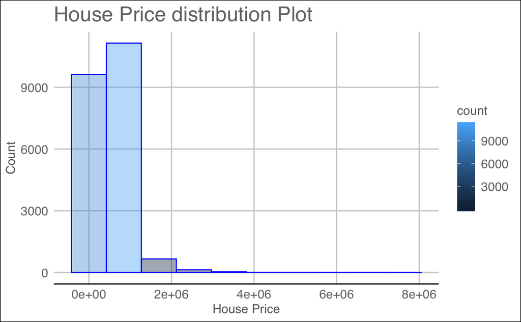

```r
library(ggplot2)
library(ggthemes)
theme_set(theme_gdocs())
ggplot(kc_house, aes(x=price)) + geom_histogram(bins = 10, color = 'blue', aes(fill=..count..), alpha = 0.4) + xlab('House Price') + ylab('Count') + ggtitle('House Price distribution Plot')
```

#### 3) cleaning & removing the unrelated and insignificant columns

removing id

```r
kc_house <- kc_house[,-c(1)]
```

removing the lat, long, zipcode

```r
kc_house <- kc_house[,-c(18,16,17)]
```

sqft_living, sqft_lot are related and can calculate sqft_living15, sqft_lot15 resp.

```r
kc_house <- kc_house[,-c(17,16)]
```

cheking NAs

```r
apply(X = kc_house,MARGIN =  2, FUN = function(col) any(is.na(col))) # no NAs
```

```
         date         price      bedrooms     bathrooms   sqft_living      sqft_lot
        FALSE         FALSE         FALSE         FALSE         FALSE         FALSE
       floors    waterfront          view     condition         grade    sqft_above
        FALSE         FALSE         FALSE         FALSE         FALSE         FALSE
sqft_basement      yr_built  yr_renovated
        FALSE         FALSE         FALSE
```

#### 4) exploring the colmuns for outliers and influential points

```r
table(kc_house$bedrooms)
```

```
   0    1    2    3    4    5    6    7    8    9   10   11   33
  13  199 2760 9824 6882 1601  272   38   13    6    3    1    1
```

33 bedroom seems to be a influential point

```r
kc_house <- kc_house[kc_house$bedrooms != 33,]
```

Column - bathrooms

```r
table(kc_house$bathrooms)
```

```
   0  0.5 0.75    1 1.25  1.5 1.75    2 2.25  2.5 2.75    3 3.25  3.5 3.75    4 4.25  4.5
  10    4   72 3852    9 1446 3047 1930 2047 5380 1185  753  589  731  155  136   79  100
4.75    5 5.25  5.5 5.75    6 6.25  6.5 6.75  7.5 7.75    8
  23   21   13   10    4    6    2    2    2    1    1    2
```

Column - View

```r
table(kc_house$view)
```

```
    0     1     2     3     4
19488   332   963   510   319
```

Resetting the row names to index

```r
row.names(kc_house) <- 1:21612
```

### Step 3.1 - Data transformation - default price

coverting the date field type from chr to date

```r
kc_house$date <- as.Date(kc_house$date, format = "%Y%m%d")
summary(kc_house$date)
```

```
        Min.      1st Qu.       Median         Mean      3rd Qu.         Max.
"2014-05-02" "2014-07-22" "2014-10-16" "2014-10-29" "2015-02-17" "2015-05-27"
```

Date is almost for the same duration of time, so the sample is unbiased remove date

```r
kc_house <- kc_house[,-c(1)]
```

converting the waterfront to factors (0,1)

```r
table(kc_house$waterfront)
```

```
    0     1
21449   163
```

```r
kc_house$waterfront <- as.factor(kc_house$waterfront)
```

### Step 4.1 : Training a model on the data - default price

adding the libraries required

```r
library(boot)
library(car)
library(leaps)
library(psych)
```

checking correlation

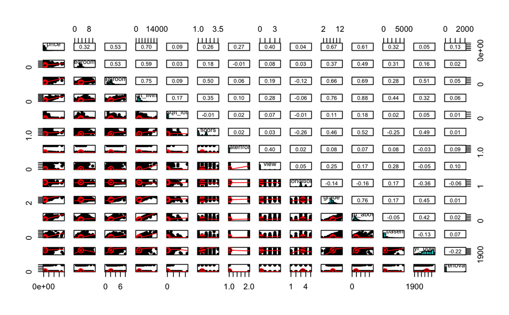

```r
pairs.panels(kc_house)
```

Model the linear model simple model 1

```r
house.fit1 <- glm(price ~ ., data = kc_house)
```

### Step 5.1 : Evaluating the model

Checking the summary of the model

```r
summary(house.fit1)
```

```
Call:
glm(formula = price ~ ., data = kc_house)

Deviance Residuals:
     Min        1Q    Median        3Q       Max
-1333250   -109639     -9586     89402   4224404

Coefficients: (1 not defined because of singularities)
                Estimate Std. Error t value Pr(>|t|)
(Intercept)    6.219e+06  1.383e+05  44.966  < 2e-16 ***
bedrooms      -4.257e+04  2.110e+03 -20.173  < 2e-16 ***
bathrooms      4.698e+04  3.499e+03  13.430  < 2e-16 ***
sqft_living    1.739e+02  4.612e+00  37.707  < 2e-16 ***
sqft_lot      -2.607e-01  3.661e-02  -7.121 1.10e-12 ***
floors         2.413e+04  3.736e+03   6.458 1.08e-10 ***
waterfront1    5.724e+05  1.865e+04  30.695  < 2e-16 ***
view           4.491e+04  2.256e+03  19.908  < 2e-16 ***
condition      1.877e+04  2.498e+03   7.512 6.03e-14 ***
grade          1.238e+05  2.166e+03  57.132  < 2e-16 ***
sqft_above    -1.547e+00  4.455e+00  -0.347   0.7284
sqft_basement         NA         NA      NA       NA
yr_built      -3.578e+03  7.087e+01 -50.490  < 2e-16 ***
yr_renovated   8.362e+00  3.914e+00   2.136   0.0327 *
---
Signif. codes:  0 ‘***’ 0.001 ‘**’ 0.01 ‘*’ 0.05 ‘.’ 0.1 ‘ ’ 1

(Dispersion parameter for gaussian family taken to be 46805833545)

    Null deviance: 2.9129e+15  on 21611  degrees of freedom
Residual deviance: 1.0110e+15  on 21599  degrees of freedom
AIC: 592338

Number of Fisher Scoring iterations: 2
```

### Step 6.1 : Improving the model

#### 1) Adding all the possible relation to the model

Model 2 - step backward

```r
house.fit2 <- step(house.fit1)
```

```
Start:  AIC=592338.3
price ~ bedrooms + bathrooms + sqft_living + sqft_lot + floors +
    waterfront + view + condition + grade + sqft_above + sqft_basement +
    yr_built + yr_renovated


Step:  AIC=592338.3
price ~ bedrooms + bathrooms + sqft_living + sqft_lot + floors +
    waterfront + view + condition + grade + sqft_above + yr_built +
    yr_renovated

               Df   Deviance    AIC
- sqft_above    1 1.0110e+15 592336
<none>            1.0110e+15 592338
- yr_renovated  1 1.0112e+15 592341
- floors        1 1.0129e+15 592378
- sqft_lot      1 1.0133e+15 592387
- condition     1 1.0136e+15 592393
- bathrooms     1 1.0194e+15 592516
- view          1 1.0295e+15 592729
- bedrooms      1 1.0300e+15 592740
- waterfront    1 1.0551e+15 593259
- sqft_living   1 1.0775e+15 593714
- yr_built      1 1.1303e+15 594747
- grade         1 1.1637e+15 595378

Step:  AIC=592336.5
price ~ bedrooms + bathrooms + sqft_living + sqft_lot + floors +
    waterfront + view + condition + grade + yr_built + yr_renovated

               Df   Deviance    AIC
<none>            1.0110e+15 592336
- yr_renovated  1 1.0112e+15 592339
- floors        1 1.0132e+15 592382
- sqft_lot      1 1.0134e+15 592386
- condition     1 1.0136e+15 592391
- bathrooms     1 1.0198e+15 592522
- bedrooms      1 1.0300e+15 592738
- view          1 1.0301e+15 592740
- waterfront    1 1.0551e+15 593257
- yr_built      1 1.1319e+15 594777
- sqft_living   1 1.1400e+15 594930
- grade         1 1.1674e+15 595443
```

```r
summary(house.fit2)
```

```
Call:
glm(formula = price ~ bedrooms + bathrooms + sqft_living + sqft_lot +
    floors + waterfront + view + condition + grade + yr_built +
    yr_renovated, data = kc_house)

Deviance Residuals:
     Min        1Q    Median        3Q       Max
-1333829   -109621     -9637     89527   4224470

Coefficients:
               Estimate Std. Error t value Pr(>|t|)
(Intercept)   6.225e+06  1.372e+05  45.354  < 2e-16 ***
bedrooms     -4.257e+04  2.110e+03 -20.173  < 2e-16 ***
bathrooms     4.720e+04  3.444e+03  13.705  < 2e-16 ***
sqft_living   1.728e+02  3.291e+00  52.502  < 2e-16 ***
sqft_lot     -2.622e-01  3.638e-02  -7.206 5.93e-13 ***
floors        2.361e+04  3.425e+03   6.893 5.61e-12 ***
waterfront1   5.722e+05  1.864e+04  30.700  < 2e-16 ***
view          4.504e+04  2.226e+03  20.229  < 2e-16 ***
condition     1.882e+04  2.494e+03   7.549 4.55e-14 ***
grade         1.237e+05  2.139e+03  57.806  < 2e-16 ***
yr_built     -3.581e+03  7.045e+01 -50.834  < 2e-16 ***
yr_renovated  8.360e+00  3.914e+00   2.136   0.0327 *
---
Signif. codes:  0 ‘***’ 0.001 ‘**’ 0.01 ‘*’ 0.05 ‘.’ 0.1 ‘ ’ 1

(Dispersion parameter for gaussian family taken to be 46803927929)

    Null deviance: 2.9129e+15  on 21611  degrees of freedom
Residual deviance: 1.0110e+15  on 21600  degrees of freedom
AIC: 592336

Number of Fisher Scoring iterations: 2
```

Model 3 - adding interaction

```r
house.fit3 <- update(house.fit2, ~ . + bedrooms:bathrooms + bedrooms:grade + bedrooms:sqft_above + bedrooms:sqft_living + bathrooms:grade + bathrooms:sqft_above + sqft_above:sqft_living + grade:sqft_living + bathrooms:sqft_living + floors:sqft_living + view:sqft_living + floors:condition + floors:grade + floors:sqft_above + waterfront:view + view:grade)
summary(house.fit3)
```

```
Call:
glm(formula = price ~ bedrooms + bathrooms + sqft_living + sqft_lot +
    floors + waterfront + view + condition + grade + yr_built +
    yr_renovated + bedrooms:bathrooms + bedrooms:grade + bedrooms:sqft_above +
    bedrooms:sqft_living + bathrooms:grade + bathrooms:sqft_above +
    sqft_living:sqft_above + sqft_living:grade + bathrooms:sqft_living +
    sqft_living:floors + sqft_living:view + floors:condition +
    floors:grade + floors:sqft_above + waterfront:view + view:grade,
    data = kc_house)

Deviance Residuals:
     Min        1Q    Median        3Q       Max
-3001706   -103399    -11999     83139   3054376

Coefficients:
                         Estimate Std. Error t value Pr(>|t|)
(Intercept)             5.716e+06  1.375e+05  41.564  < 2e-16 ***
bedrooms               -3.110e+04  1.394e+04  -2.231 0.025709 *
bathrooms              -6.255e+04  2.517e+04  -2.485 0.012954 *
sqft_living            -6.570e+01  2.229e+01  -2.947 0.003210 **
sqft_lot               -2.723e-01  3.425e-02  -7.951 1.93e-15 ***
floors                  1.035e+03  3.284e+04   0.032 0.974851
waterfront1             3.368e+05  1.080e+05   3.120 0.001813 **
view                   -1.058e+05  1.331e+04  -7.950 1.95e-15 ***
condition              -1.935e+04  6.975e+03  -2.774 0.005548 **
grade                   1.932e+04  7.935e+03   2.434 0.014924 *
yr_built               -2.908e+03  7.076e+01 -41.097  < 2e-16 ***
yr_renovated            2.198e+01  3.668e+00   5.992 2.10e-09 ***
bedrooms:bathrooms      4.392e+02  2.876e+03   0.153 0.878633
bedrooms:grade          2.865e+03  2.327e+03   1.231 0.218324
bedrooms:sqft_above     1.413e+01  3.542e+00   3.988 6.68e-05 ***
bedrooms:sqft_living   -1.365e+01  3.814e+00  -3.579 0.000346 ***
bathrooms:grade         1.202e+04  3.670e+03   3.276 0.001056 **
bathrooms:sqft_above    9.760e+00  6.220e+00   1.569 0.116638
sqft_living:sqft_above  1.589e-02  3.240e-03   4.903 9.48e-07 ***
sqft_living:grade       2.554e+01  2.769e+00   9.224  < 2e-16 ***
bathrooms:sqft_living  -2.797e+00  4.820e+00  -0.580 0.561662
sqft_living:floors      1.981e+01  7.309e+00   2.710 0.006736 **
sqft_living:view        3.290e+00  2.522e+00   1.305 0.192005
floors:condition        3.679e+04  5.154e+03   7.138 9.74e-13 ***
floors:grade            5.240e+03  4.043e+03   1.296 0.194987
floors:sqft_above      -9.259e+01  8.524e+00 -10.862  < 2e-16 ***
waterfront1:view        5.474e+04  2.844e+04   1.925 0.054250 .
view:grade              1.596e+04  2.075e+03   7.688 1.56e-14 ***
---
Signif. codes:  0 ‘***’ 0.001 ‘**’ 0.01 ‘*’ 0.05 ‘.’ 0.1 ‘ ’ 1

(Dispersion parameter for gaussian family taken to be 40618975037)

    Null deviance: 2.9129e+15  on 21611  degrees of freedom
Residual deviance: 8.7672e+14  on 21584  degrees of freedom
AIC: 589289

Number of Fisher Scoring iterations: 2
```

Model 4 - step backward

```r
house.fit4 <- step(house.fit3)
```

```
Start:  AIC=589289.3
price ~ bedrooms + bathrooms + sqft_living + sqft_lot + floors +
    waterfront + view + condition + grade + yr_built + yr_renovated +
    bedrooms:bathrooms + bedrooms:grade + bedrooms:sqft_above +
    bedrooms:sqft_living + bathrooms:grade + bathrooms:sqft_above +
    sqft_living:sqft_above + sqft_living:grade + bathrooms:sqft_living +
    sqft_living:floors + sqft_living:view + floors:condition +
    floors:grade + floors:sqft_above + waterfront:view + view:grade

                         Df   Deviance    AIC
- bedrooms:bathrooms      1 8.7672e+14 589287
- bathrooms:sqft_living   1 8.7673e+14 589288
- bedrooms:grade          1 8.7678e+14 589289
- floors:grade            1 8.7679e+14 589289
- sqft_living:view        1 8.7679e+14 589289
<none>                      8.7672e+14 589289
- bathrooms:sqft_above    1 8.7682e+14 589290
- waterfront:view         1 8.7687e+14 589291
- sqft_living:floors      1 8.7702e+14 589295
- bathrooms:grade         1 8.7716e+14 589298
- bedrooms:sqft_living    1 8.7724e+14 589300
- bedrooms:sqft_above     1 8.7737e+14 589303
- sqft_living:sqft_above  1 8.7770e+14 589311
- yr_renovated            1 8.7818e+14 589323
- floors:condition        1 8.7879e+14 589338
- view:grade              1 8.7912e+14 589346
- sqft_lot                1 8.7929e+14 589351
- sqft_living:grade       1 8.8018e+14 589372
- floors:sqft_above       1 8.8151e+14 589405
- yr_built                1 9.4533e+14 590916

Step:  AIC=589287.4
price ~ bedrooms + bathrooms + sqft_living + sqft_lot + floors +
    waterfront + view + condition + grade + yr_built + yr_renovated +
    bedrooms:grade + bedrooms:sqft_above + bedrooms:sqft_living +
    bathrooms:grade + bathrooms:sqft_above + sqft_living:sqft_above +
    sqft_living:grade + bathrooms:sqft_living + sqft_living:floors +
    sqft_living:view + floors:condition + floors:grade + floors:sqft_above +
    waterfront:view + view:grade

```

[output cut: 136 more lines]

```
                         Df   Deviance    AIC
<none>                      8.7700e+14 589284
- waterfront:view         1 8.7717e+14 589286
- sqft_living:floors      1 8.7741e+14 589292
- bedrooms:sqft_living    1 8.7791e+14 589305
- bedrooms:sqft_above     1 8.7825e+14 589313
- yr_renovated            1 8.7844e+14 589318
- floors:condition        1 8.7902e+14 589332
- bathrooms:grade         1 8.7909e+14 589334
- sqft_lot                1 8.7959e+14 589346
- sqft_living:sqft_above  1 8.8056e+14 589370
- sqft_living:grade       1 8.8174e+14 589399
- floors:sqft_above       1 8.8259e+14 589419
- view:grade              1 8.8404e+14 589455
- yr_built                1 9.4657e+14 590932
```

```r
summary(house.fit4)
```

```
Call:
glm(formula = price ~ bedrooms + bathrooms + sqft_living + sqft_lot +
    floors + waterfront + view + condition + grade + yr_built +
    yr_renovated + bedrooms:sqft_above + bedrooms:sqft_living +
    bathrooms:grade + sqft_living:sqft_above + sqft_living:grade +
    sqft_living:floors + floors:condition + floors:sqft_above +
    waterfront:view + view:grade, data = kc_house)

Deviance Residuals:
     Min        1Q    Median        3Q       Max
-2997702   -103016    -11864     83295   3035153

Coefficients:
                         Estimate Std. Error t value Pr(>|t|)
(Intercept)             5.669e+06  1.318e+05  43.009  < 2e-16 ***
bedrooms               -1.499e+04  4.625e+03  -3.242  0.00119 **
bathrooms              -8.380e+04  1.843e+04  -4.548 5.44e-06 ***
sqft_living            -7.516e+01  1.678e+01  -4.481 7.48e-06 ***
sqft_lot               -2.732e-01  3.423e-02  -7.980 1.54e-15 ***
floors                  3.257e+04  1.851e+04   1.760  0.07848 .
waterfront1             3.275e+05  1.078e+05   3.039  0.00238 **
view                   -1.113e+05  1.158e+04  -9.615  < 2e-16 ***
condition              -1.828e+04  6.918e+03  -2.642  0.00825 **
grade                   2.817e+04  4.598e+03   6.126 9.18e-10 ***
yr_built               -2.911e+03  7.034e+01 -41.384  < 2e-16 ***
yr_renovated            2.183e+01  3.664e+00   5.957 2.61e-09 ***
bedrooms:sqft_above     1.637e+01  2.950e+00   5.550 2.89e-08 ***
bedrooms:sqft_living   -1.254e+01  2.651e+00  -4.732 2.24e-06 ***
bathrooms:grade         1.655e+04  2.309e+03   7.166 7.96e-13 ***
sqft_living:sqft_above  1.806e-02  1.930e-03   9.356  < 2e-16 ***
sqft_living:grade       2.488e+01  2.305e+00  10.798  < 2e-16 ***
sqft_living:floors      1.994e+01  6.295e+00   3.167  0.00154 **
floors:condition        3.602e+04  5.111e+03   7.048 1.88e-12 ***
floors:sqft_above      -8.625e+01  7.357e+00 -11.723  < 2e-16 ***
waterfront1:view        5.746e+04  2.837e+04   2.026  0.04281 *
view:grade              1.766e+04  1.341e+03  13.166  < 2e-16 ***
---
Signif. codes:  0 ‘***’ 0.001 ‘**’ 0.01 ‘*’ 0.05 ‘.’ 0.1 ‘ ’ 1

(Dispersion parameter for gaussian family taken to be 40620783423)

    Null deviance: 2.9129e+15  on 21611  degrees of freedom
Residual deviance: 8.7700e+14  on 21590  degrees of freedom
AIC: 589284

Number of Fisher Scoring iterations: 2
```

```r
house.fit5 <- update(house.fit2, ~ . - floors)
summary(house.fit5)
```

```
Call:
glm(formula = price ~ bedrooms + bathrooms + sqft_living + sqft_lot +
    waterfront + view + condition + grade + yr_built + yr_renovated,
    data = kc_house)

Deviance Residuals:
     Min        1Q    Median        3Q       Max
-1333039   -111146     -9348     90687   4226547

Coefficients:
               Estimate Std. Error t value Pr(>|t|)
(Intercept)   6.044e+06  1.349e+05  44.814  < 2e-16 ***
bedrooms     -4.318e+04  2.111e+03 -20.460  < 2e-16 ***
bathrooms     5.268e+04  3.354e+03  15.706  < 2e-16 ***
sqft_living   1.712e+02  3.287e+00  52.096  < 2e-16 ***
sqft_lot     -2.778e-01  3.635e-02  -7.642 2.23e-14 ***
waterfront1   5.749e+05  1.866e+04  30.820  < 2e-16 ***
view          4.425e+04  2.226e+03  19.878  < 2e-16 ***
condition     1.674e+04  2.478e+03   6.756 1.46e-11 ***
grade         1.262e+05  2.109e+03  59.858  < 2e-16 ***
yr_built     -3.481e+03  6.901e+01 -50.441  < 2e-16 ***
yr_renovated  9.696e+00  3.914e+00   2.477   0.0132 *
---
Signif. codes:  0 ‘***’ 0.001 ‘**’ 0.01 ‘*’ 0.05 ‘.’ 0.1 ‘ ’ 1

(Dispersion parameter for gaussian family taken to be 46904710295)

    Null deviance: 2.9129e+15  on 21611  degrees of freedom
Residual deviance: 1.0132e+15  on 21601  degrees of freedom
AIC: 592382

Number of Fisher Scoring iterations: 2
```

#### 2) check the best fit by ignoring uncorrelated variables

checking the best predictors to predict the house price

```r
bstFits1 <- regsubsets(price ~ bedrooms+bathrooms+sqft_living+sqft_lot+floors+waterfront+view+condition+grade+sqft_above+sqft_basement+yr_built+yr_renovated, data = kc_house, nbest = 1, nvmax = 6)
```

```
1  linear dependencies found
```

```
Reordering variables and trying again:
```

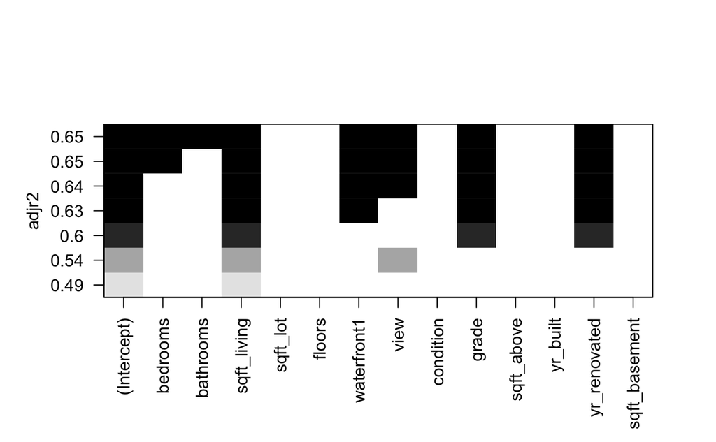

```r
par(mfrow = c(1,1))
#subsets(bstFits1, statistic = "adjr2", max.size = 6)
plot(bstFits1, scale = "adjr2")
```

Doing cross-validation for 4 predictors using K-Fold

```r
house.k10.4 <- glm(price ~ sqft_living + waterfront + yr_renovated + grade, data = kc_house)
summary(house.k10.4) # 596532
```

```
Call:
glm(formula = price ~ sqft_living + waterfront + yr_renovated +
    grade, data = kc_house)

Deviance Residuals:
     Min        1Q    Median        3Q       Max
-1342077   -132453    -21816     99973   4761201

Coefficients:
               Estimate Std. Error t value Pr(>|t|)
(Intercept)  -5.970e+05  1.268e+04  -47.09   <2e-16 ***
sqft_living   1.737e+02  2.741e+00   63.37   <2e-16 ***
waterfront1   7.950e+05  1.892e+04   42.02   <2e-16 ***
yr_renovated  7.346e+01  4.063e+00   18.08   <2e-16 ***
grade         9.973e+04  2.135e+03   46.70   <2e-16 ***
---
Signif. codes:  0 ‘***’ 0.001 ‘**’ 0.01 ‘*’ 0.05 ‘.’ 0.1 ‘ ’ 1

(Dispersion parameter for gaussian family taken to be 56850059198)

    Null deviance: 2.9129e+15  on 21611  degrees of freedom
Residual deviance: 1.2284e+15  on 21607  degrees of freedom
AIC: 596532

Number of Fisher Scoring iterations: 2
```

```r
house.k10.4.err <- cv.glm(data = kc_house,glmfit = house.k10.4, K = 10)
round(house.k10.4.err$delta[1], 4) # 56952103727
```

```
[1] 56952103727
```

Checking the r square and adj. r square values

```r
house.k10.4.lm <- lm(price ~ sqft_living + waterfront + yr_renovated + grade, data = kc_house)
summary(house.k10.4.lm)
```

```
Call:
lm(formula = price ~ sqft_living + waterfront + yr_renovated +
    grade, data = kc_house)

Residuals:
     Min       1Q   Median       3Q      Max
-1342077  -132453   -21816    99973  4761201

Coefficients:
               Estimate Std. Error t value Pr(>|t|)
(Intercept)  -5.970e+05  1.268e+04  -47.09   <2e-16 ***
sqft_living   1.737e+02  2.741e+00   63.37   <2e-16 ***
waterfront1   7.950e+05  1.892e+04   42.02   <2e-16 ***
yr_renovated  7.346e+01  4.063e+00   18.08   <2e-16 ***
grade         9.973e+04  2.135e+03   46.70   <2e-16 ***
---
Signif. codes:  0 ‘***’ 0.001 ‘**’ 0.01 ‘*’ 0.05 ‘.’ 0.1 ‘ ’ 1

Residual standard error: 238400 on 21607 degrees of freedom
Multiple R-squared:  0.5783,    Adjusted R-squared:  0.5782
F-statistic:  7408 on 4 and 21607 DF,  p-value: < 2.2e-16
```

Plot the model

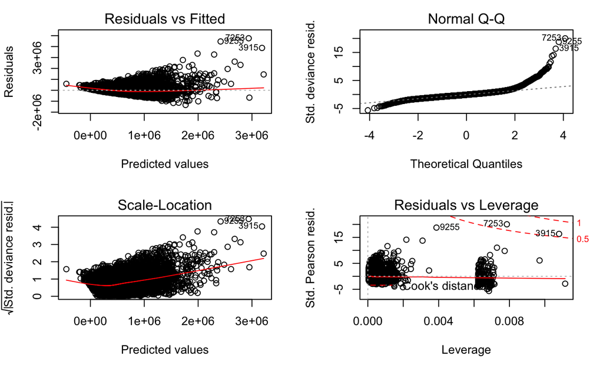

```r
par(mfrow = c(2,2))
plot(house.k10.4)
```